# KNN ile Zaman Serisi Tahmini: tsfknn Paketi

Sefa Aksüngü & İrem Soylu

25 Ocak 2021

###### $~$$~$ Bu ödevde, k-en yakın komşu regresyonunu kullanarak zaman serisi tahmini için tsfknn paketini açıklamaya çalışacağız. Bu paket, kullanıcıların bir KNN modeli belirlemesine ve tahminlerini oluşturmasına olanak tanımaktadır. Kullanıcı, en yakın komşuların hedeflerini bir araya getirmek için farklı çok adımlı ileri stratejiler ve farklı fonksiyonlar arasından seçim yapabilmektedir. Bu paket KNN modelinin tahmin doğruluğunu değerlendirmeye imkan vermektedir.

# KNN(k Nearest Neighbours)

$~$$~$ Hem sınıflandırma hem de regresyon problemlerinin çözümünde kullanılıyor olmakla birlikte, endüstride çoğunlukla sınıflandırma problemlerinin çözümünde kullanılmaktadır. KNN algoritmaları, 1967 yılında T. M. Cover ve P. E. Hart tarafından önerilmiştir. Algoritma, sınıfları belli olan bir örnek kümesindeki verilerden yararlanılarak kullanılmaktadır. Örnek veri setine katılacak olan yeni verinin, mevcut verilere göre uzaklığı hesaplanıp, k sayıda yakın komşuluğuna bakılır.

Uzaklık hesapları için genelde 3 tip uzaklık fonksiyonu kullanılmaktadır:

- Oklid uzaklığı
- Minkowski uzaklığı
- Manhattan uzaklığı

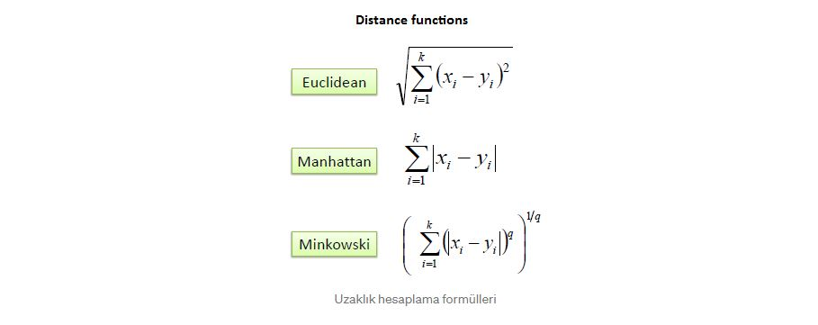

$~$$~$ K-NN ( K-Nearest Neighbor) algoritması en çok kullanılan sınıflandırma algoritmasından biridir.

Adımlar

KNN_Algoritmasının_Adımları

1. Adım

Sınıf nitelikleri belli olan elemanlardan oluşan bir uzaya yeni bir örnek ekle.

2. Adım

K sayısını belirle.

3. Adım

Yeni gelen örnek ile elemanlar arasındaki uzaklığı hesapla.(Uzaklık fonksiyonlardan birini kullanarak)

4. Adım

En yakın olan k tane elemanın sınıf niteliğine bak.

5. Adım

En yakın olan k tane elemanlardan sınıf değeri sayıca fazla olan sınıfa örneği dahil et.

KNN en basit anlamı ile içerisinde tahmin edilecek değerin bağımsız değişkenlerinin oluşturduğu vektörün en yakın komşularının hangi sınıfta yoğun olduğu bilgisi üzerinden sınıfını tahmin etmeye dayanır.

| Boy_Verisi | Kilo_Verisi | Cinsiyet |
| --- | --- | --- |
| 180 | 80 | Erkek |
| 170 | 70 | Erkek |
| 150 | 65 | Kadın |
| 160 | 55 | Kadın |
| 175 | 65 | Kadın |
| 185 | 90 | Erkek |
| 173 | 100 | Erkek |
| 183 | 110 | Erkek |
| 153 | 60 | Kadın |
| 163 | 45 | Kadın |

```r
KNN_Cinsiyet<-function(dataSet,boy,kilo,k){
  euclid <- c()
  for (i in 1:nrow(dataSet)){
    euclid <- append(euclid,sqrt(sum((dataSet[i,1:2]-c(boy,kilo)) ^ 2)))
  }
  enYakinKData <- as.data.frame(euclid)
  enYakinKData <- data.frame(Satir_No=row(enYakinKData),Oklid_Mesafeleri=euclid)
  enYakinKDataOrder <- enYakinKData[order(enYakinKData$Oklid_Mesafeleri),]
  enYakinKDataOrder2 <- cbind(enYakinKDataOrder,Cinsiyet=data[enYakinKDataOrder$Satir_No,3])
  countx<-count(enYakinKDataOrder2[1:k,],Cinsiyet)
  if (nrow(countx) == 1){
    sonuc <- countx[1,]$Cinsiyet
  } else if (countx[1,]$n > countx[2,]$n) {
    sonuc <- countx[1,]$Cinsiyet
  } else if(countx[1,]$n == countx[2,]$n){
    sonuc <- "En yakın komşu sayısı eşit çıkmıştır."
  } else {
    sonuc <- countx[2,]$Cinsiyet
  }
  return(sonuc)
}
```

```r
KNN_Cinsiyet(data,160,70,3)
```

```
## [1] "Kadın"
```

# Zaman Serisi Nedir?

$~$$~$ Bir zaman serisi, ilgilenilen bir büyüklüğün zaman içerisinde sıralanmış ölçümlerinin bir kümesidir. Zaman serisi ile ilgili bu analizin yapılma amacı ise, gözlem kümesince temsil edilen gerçeğin anlaşılması ve zaman serisindeki değişkenlerin gelecekteki değerlerinin doğru bir şekilde tahmin (forecast) edilmesidir .

- Zaman serisi analizi; zaman içerisinde gelişen olayların ve işlemlerin analiz edilmesi ve iç görüye dönüştürülmesi ile tarihsel etkileri anlamak için önemli bir tekniktir.
- Zaman serileri; zamana göre (kronolojik) sıralanan veri dizileridir, veri satırları periyodik (saat, gün, ay, yıl vb.) bir döngü ile sıralanırlar.
- Zaman serileri sayısal olarak ifade edilebilecek olayların ve işlemlerin bir zaman damgası ile ilişkilendirildiği basit veri setleri olarak da tanımlanabilir.

*“Bir zaman serisi, zaman içinden alınan ardışık bir dizi gözlemdir.”*

**Örneğin;**

$~$$~$ Bir insanın gün içerisinde attığı adım sayısı bir zaman serisi örneğidir, günler ile işaretlenecek olan adım sayıları, günler ile birlikte bir zaman serisi oluşturmaktadır.

Bu örnekte gün serinin zaman boyutudur, adım sayısı ise gözlemdir.

| Günler_Zaman | Adım_Sayısı_Gözlem |
| --- | --- |
| 21-01-2020 | 2236 |
| 22-01-2020 | 1652 |
| 23-01-2020 | 1725 |
| 24-01-2020 | 2699 |
| 25-01-2020 | 2756 |

**Bir başka örnek;**

$~$$~$ Bir işletmenin aylık satış verilerinin zaman damgası ile işaretli olduğu ve zaman üzerinde sıralanmış olduğu bir veri seti; zaman serisi verisidir, bu veri setinde zaman boyutu aylar, gözlemler ise satışlarla temsil edilmiş olur.

| Ay_Zaman | Satışlar_Gözlem |
| --- | --- |
| Ocak | 210.010 TL |
| Şubat | 230.883 TL |
| Mart | 210.603 TL |
| Nisan | 260.218 TL |
| Mayıs | 280.368 TL |

$~$$~$ **Zaman serileri analizlerinde kullanılan bazı grafikler:**

**time series plot**

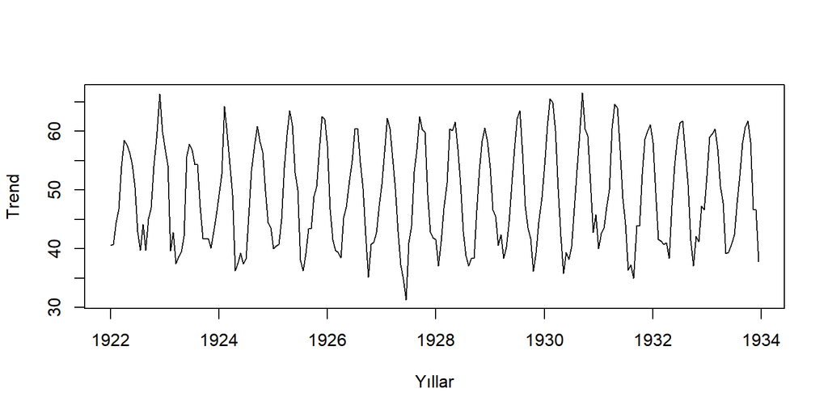

```r
data = ts(nottem, start=1922, frequency=20)
plot(data, ylab = "Trend", xlab = "Yıllar")
```

**Mevsimsel Çizelge (Seasonal Plot)**

$~$$~$ Seasonal plot; farklı yıllardaki zaman serilerini üst üste görselleştirerek, her bir yılın sezonsal farklılığını ve ortak yanlarını anlamamıza yardımcı olan veri görselleştirme aracıdır.

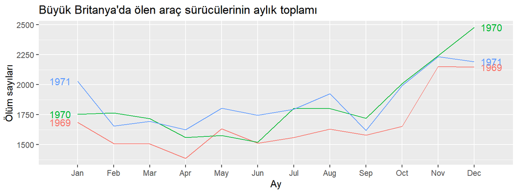

```r
mimoTimeS <- window(UKDriverDeaths,end=c(1971,12))
ggseasonplot(mimoTimeS, year.labels=TRUE, year.labels.left=TRUE) +
ylab("Ölüm sayıları") +
xlab("Ay") +
ggtitle("Büyük Britanya'da ölen araç sürücülerinin aylık toplamı")
```

**Polar Seasonal Plot**

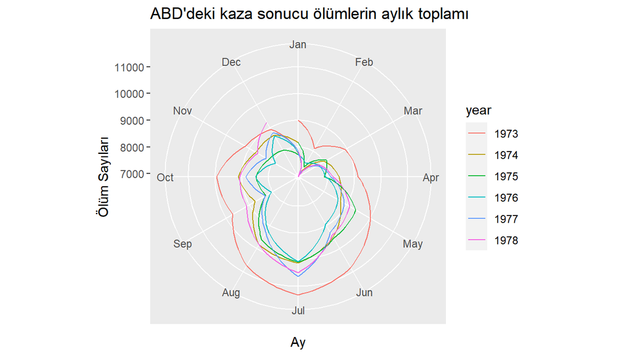

```r
ggseasonplot(USAccDeaths, polar=TRUE) +
ylab("Ölüm Sayıları") +
xlab("Ay") +
ggtitle("ABD'deki kaza sonucu ölümlerin aylık toplamı")
```

# R programında KNN ile Zaman Serisi Tahmini: tsfknn Paketi

$~$$~$ i. eğitim örneği, n özellikli bir vektör : $f^{i}_{1},f^{i}_{2},f^{i}_{3},...,f^{i}_{n}$, ve örneği açıklayan ve onunla ilişkili m öznitelikli hedef vektörü $t^{i}_{1},t^{i}_{2},t^{i}_{3},...,t^{i}_{n}$. vektöründen oluşur. Özellikleri bilinen ancak hedefi bilinmeyen yeni bir örnek verildiğinde, yeni örneğin özellikleri, özelliklerin vektörlerine ve bir benzerlik veya uzaklık ölçüsüne göre “k” en benzer eğitim örneklerini bulmak için kullanılır. Örneğin, benzerlik metriğinin Öklid mesafesi olduğunu varsayarsak, yeni örnek ile i. eğitim örneği arasındaki mesafe aşağıdaki gibi hesaplanır:

$$Öklid=\sqrt{\sum_{x=1}^n (e_x^i-q_x)^2}$$

$~$$~$ Kısacası, KNN n özellik tarafından tanımlanan eğitim örneklerinin bir koleksiyonunu depolar. Her eğitim örneği, n boyutlu bir uzaydaki bir noktayı temsil eder. Yeni bir örnek verildiğinde, KNN, mevcut hedeflerinin bilinmeyen hedefe benzer olması umuduyla n boyutlu uzayda k en yakın örneklerini bulur. Bir eğitim örneğiyle ilişkili hedef değeri, zaman serilerinin değerlerinin bir koleksiyonudur ve örneği açıklayan özellikler, hedefin gecikmeli değerleridir. Bir eğitim örneğinin hedefi zaman serisinin bir değeri olduğundan yalnızca bir değer tahmin edilecektir.

$~$$~$ Zaman serisi tahmini için KNN kullanımının arkasındaki mantık, bir zaman serisinin tekrarlayan modeller içerebilmesidir. Bir zaman serisinin son modeli göz önüne alındığında, sonraki modellerinin zaman serisinin gelecekteki değerlerine benzer olacağı ümidiyle geçmişte benzer kalıplar ararız.

$~$$~$ Knn_examples ile eğitim örneklerine başvurmadan önce, modeli oluşturmak gerekir. Bu, bir zaman serisiyle ilişkili bir model oluşturan ve modeli zaman serisinin gelecekteki değerlerini tahmin etmek için kullanan knn_forecasting fonksiyonu ile yapılır. knn_forecasting çok kullanışlıdır çünkü KNN modelini oluşturur ve daha sonra modeli zaman serilerini tahmin etmek için kullanır. Modelle ilgili eğitim örneklerini görmek için knn_examples fonksiyonu kullanılabilir.

- Örneklere başlamadan önce paket içerisinde yer alan fonksiyonları ve argümanlarını incelersek:

**Tsfknn paketindeki fonksiyonlar ve yöntemler**

[output not shown]

[output not shown]

| Features | Target |
| --- | --- |
| $X_{1}$,$X_{2}$,$X_{3}$,$X_{4}$,$X_{5}$,$X_{6}$,$X_{7}$,$X_{8}$,$X_{9}$,$X_{10}$,$X_{11}$,$X_{12}$ | $X_{13}$ |
| $X_{2}$,$X_{3}$,$X_{4}$,$X_{5}$,$X_{6}$,$X_{7}$,$X_{8}$,$X_{9}$,$X_{10}$,$X_{11}$,$X_{12}$,$X_{13}$ | $X_{14}$ |
| $X_{3}$,$X_{4}$,$X_{5}$,$X_{6}$,$X_{7}$,$X_{8}$,$X_{9}$,$X_{10}$,$X_{11}$,$X_{12}$,$X_{13}$,$X_{14}$ | $X_{15}$ |
| … | … |
| $X_{120}$,$X_{121}$,$X_{122}$,$X_{123}$,$X_{124}$,$X_{125}$,$X_{126}$,$X_{127}$,$X_{128}$,$X_{129}$,$X_{130}$,$X_{131}$ | $X_{132}$ |

**tsfknn paketinin bir zaman serisini tahmin etmek için nasıl kullanılmaktadır ?**

```
##       Jan  Feb  Mar  Apr  May  Jun  Jul  Aug  Sep  Oct  Nov  Dec
## 1920 40.6 40.8 44.4 46.7 54.1 58.5 57.7 56.4 54.3 50.5 42.9 39.8
## 1921 44.2 39.8 45.1 47.0 54.1 58.7 66.3 59.9 57.0 54.2 39.7 42.8
## 1922 37.5 38.7 39.5 42.1 55.7 57.8 56.8 54.3 54.3 47.1 41.8 41.7
## 1923 41.8 40.1 42.9 45.8 49.2 52.7 64.2 59.6 54.4 49.2 36.3 37.6
## 1924 39.3 37.5 38.3 45.5 53.2 57.7 60.8 58.2 56.4 49.8 44.4 43.6
## 1925 40.0 40.5 40.8 45.1 53.8 59.4 63.5 61.0 53.0 50.0 38.1 36.3
## 1926 39.2 43.4 43.4 48.9 50.6 56.8 62.5 62.0 57.5 46.7 41.6 39.8
## 1927 39.4 38.5 45.3 47.1 51.7 55.0 60.4 60.5 54.7 50.3 42.3 35.2
## 1928 40.8 41.1 42.8 47.3 50.9 56.4 62.2 60.5 55.4 50.2 43.0 37.3
## 1929 34.8 31.3 41.0 43.9 53.1 56.9 62.5 60.3 59.8 49.2 42.9 41.9
## 1930 41.6 37.1 41.2 46.9 51.2 60.4 60.1 61.6 57.0 50.9 43.0 38.8
## 1931 37.1 38.4 38.4 46.5 53.5 58.4 60.6 58.2 53.8 46.6 45.5 40.6
## 1932 42.4 38.4 40.3 44.6 50.9 57.0 62.1 63.5 56.3 47.3 43.6 41.8
## 1933 36.2 39.3 44.5 48.7 54.2 60.8 65.5 64.9 60.1 50.2 42.1 35.8
## 1934 39.4 38.2 40.4 46.9 53.4 59.6 66.5 60.4 59.2 51.2 42.8 45.8
## 1935 40.0 42.6 43.5 47.1 50.0 60.5 64.6 64.0 56.8 48.6 44.2 36.4
## 1936 37.3 35.0 44.0 43.9 52.7 58.6 60.0 61.1 58.1 49.6 41.6 41.3
## 1937 40.8 41.0 38.4 47.4 54.1 58.6 61.4 61.8 56.3 50.9 41.4 37.1
## 1938 42.1 41.2 47.3 46.6 52.4 59.0 59.6 60.4 57.0 50.7 47.8 39.2
## 1939 39.4 40.9 42.4 47.8 52.4 58.0 60.7 61.8 58.2 46.7 46.6 37.8
```

$~$$~$ **nottem** veri seti, Nottingham Kalesi’nde 20 yıl boyunca Fahrenheit derece cinsinden ortalama hava sıcaklıklarını içeren bir zaman serisi nesnesidir.

```r
class(nottem)
```

```
## [1] "ts"
```

$~$$~$ Bu veri setinin classına baktığımızda “ts” olduğunu görüyoruz. “ts” fonksiyonu, zaman serisi nesneleri oluşturmak için kullanılmakatadır.

$~$$~$ Örneğimizi daha iyi açıklayabilmek için veri setinde ilk 3 yılı ele alıp 1923 yılının ilk ayını tahmin etmeye çalışacağız. Bu yüzden **window** fonksiyonu ile veri setimizde kaç yılına kadar almak istiyorsak argüman olarak belirtip **timeS** değişkinene atama işlemini gerçekleştirdik. Ardından **knn_forecasting** fonksiyonu ile zaman serilerini tahmin etmek için bir KNN modeli oluşturduk ve bu zaman serilerinin gelecekteki değerlerine ilişkin bir tahmin yapmak için kullanmış olduk. Bu fonksiyon ile model ve tahmin hakkındaki bilgiler bir “knnForecast” nesnesinde döndürülür ve bu nesneyi **pred** adında oluşturduğmuz değişkene atama işlemini gerçekleştirdik. **knn_forecasting** fonksiyonuna veri setimizi, tahmin sayımızı(**h=1**), en yakın komşu olarak bakmasını istediğimiz sayıyı(**k=2**) ve gecikmeleri yani özelliklerimizi yılın ayları şeklinde tahminleyeceğimiz için 1:12 olarak yazdık. **knn_examples** fonksiyonuna pred değişkenini argüman olarak vererek bir KNN modeliyle ilişkili örnekleri görebilmiş olduk.

```r
timeS <- window(nottem,end=c(1922,12))
timeS
```

```
##       Jan  Feb  Mar  Apr  May  Jun  Jul  Aug  Sep  Oct  Nov  Dec
## 1920 40.6 40.8 44.4 46.7 54.1 58.5 57.7 56.4 54.3 50.5 42.9 39.8
## 1921 44.2 39.8 45.1 47.0 54.1 58.7 66.3 59.9 57.0 54.2 39.7 42.8
## 1922 37.5 38.7 39.5 42.1 55.7 57.8 56.8 54.3 54.3 47.1 41.8 41.7
```

```r
pred <- knn_forecasting(timeS,h=1,lags=1:12,k=2)
knn_examples(pred)
```

```
##       Lag12 Lag11 Lag10 Lag9 Lag8 Lag7 Lag6 Lag5 Lag4 Lag3 Lag2 Lag1   H1
##  [1,]  40.6  40.8  44.4 46.7 54.1 58.5 57.7 56.4 54.3 50.5 42.9 39.8 44.2
##  [2,]  40.8  44.4  46.7 54.1 58.5 57.7 56.4 54.3 50.5 42.9 39.8 44.2 39.8
##  [3,]  44.4  46.7  54.1 58.5 57.7 56.4 54.3 50.5 42.9 39.8 44.2 39.8 45.1
##  [4,]  46.7  54.1  58.5 57.7 56.4 54.3 50.5 42.9 39.8 44.2 39.8 45.1 47.0
##  [5,]  54.1  58.5  57.7 56.4 54.3 50.5 42.9 39.8 44.2 39.8 45.1 47.0 54.1
##  [6,]  58.5  57.7  56.4 54.3 50.5 42.9 39.8 44.2 39.8 45.1 47.0 54.1 58.7
##  [7,]  57.7  56.4  54.3 50.5 42.9 39.8 44.2 39.8 45.1 47.0 54.1 58.7 66.3
##  [8,]  56.4  54.3  50.5 42.9 39.8 44.2 39.8 45.1 47.0 54.1 58.7 66.3 59.9
##  [9,]  54.3  50.5  42.9 39.8 44.2 39.8 45.1 47.0 54.1 58.7 66.3 59.9 57.0
## [10,]  50.5  42.9  39.8 44.2 39.8 45.1 47.0 54.1 58.7 66.3 59.9 57.0 54.2
## [11,]  42.9  39.8  44.2 39.8 45.1 47.0 54.1 58.7 66.3 59.9 57.0 54.2 39.7
## [12,]  39.8  44.2  39.8 45.1 47.0 54.1 58.7 66.3 59.9 57.0 54.2 39.7 42.8
## [13,]  44.2  39.8  45.1 47.0 54.1 58.7 66.3 59.9 57.0 54.2 39.7 42.8 37.5
## [14,]  39.8  45.1  47.0 54.1 58.7 66.3 59.9 57.0 54.2 39.7 42.8 37.5 38.7
## [15,]  45.1  47.0  54.1 58.7 66.3 59.9 57.0 54.2 39.7 42.8 37.5 38.7 39.5
## [16,]  47.0  54.1  58.7 66.3 59.9 57.0 54.2 39.7 42.8 37.5 38.7 39.5 42.1
## [17,]  54.1  58.7  66.3 59.9 57.0 54.2 39.7 42.8 37.5 38.7 39.5 42.1 55.7
## [18,]  58.7  66.3  59.9 57.0 54.2 39.7 42.8 37.5 38.7 39.5 42.1 55.7 57.8
## [19,]  66.3  59.9  57.0 54.2 39.7 42.8 37.5 38.7 39.5 42.1 55.7 57.8 56.8
## [20,]  59.9  57.0  54.2 39.7 42.8 37.5 38.7 39.5 42.1 55.7 57.8 56.8 54.3
## [21,]  57.0  54.2  39.7 42.8 37.5 38.7 39.5 42.1 55.7 57.8 56.8 54.3 54.3
## [22,]  54.2  39.7  42.8 37.5 38.7 39.5 42.1 55.7 57.8 56.8 54.3 54.3 47.1
## [23,]  39.7  42.8  37.5 38.7 39.5 42.1 55.7 57.8 56.8 54.3 54.3 47.1 41.8
## [24,]  42.8  37.5  38.7 39.5 42.1 55.7 57.8 56.8 54.3 54.3 47.1 41.8 41.7
```

$~$$~$ Knn_examples ile eğitim örneklerine başvurmadan önce, modeli oluşturmamız gerektiğinden bahsetmiştik. Bu, bir zaman serisiyle ilişkili bir model oluşturan ve modeli zaman serisinin gelecekteki değerlerini tahmin etmek için kullanan knn_forecasting fonksiyonu ile yapabilmekteyiz.

**Peki nasıl çalışır ?**

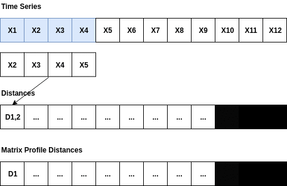

```r
# Kayan pencere algoritmasını kullanır:
#
knn_ExamplesData<-function(dataTs,lagG=12,Tsay=1){
                    features <- c()
                    targets <- c()
                    colLogs <- c()
                    colTarg <- c()
                    m <- lagG
                    for ( i in 1:length(dataTs)) {

                      features <- append(features,dataTs[i:m])
                      targets <- append(targets,dataTs[(m+1):(m+Tsay)])
                      m = m + 1
                      if (m == (length(dataTs)+1-Tsay)){
                        break
                      }
                    }

                    features <- t(matrix(features,nrow = lagG))
                    targets <- t(matrix(targets,nrow = Tsay))
                    knn_ExamplesSonuc<-cbind(features,targets)
                    for (i in (lagG):1){
                      colLogs <- append(colLogs,paste("Lag",i,sep = ""))
                    }
                    for (j in 1:Tsay){
                      colTarg <- append(colTarg,paste("H",j,sep = ""))
                    }

                    colnames(knn_ExamplesSonuc) <- c(colLogs,colTarg)

                    return(knn_ExamplesSonuc)
}
```

```r
knn_ExamplesData(timeS,lagG=12,Tsay = 1)
```

```
##       Lag12 Lag11 Lag10 Lag9 Lag8 Lag7 Lag6 Lag5 Lag4 Lag3 Lag2 Lag1   H1
##  [1,]  40.6  40.8  44.4 46.7 54.1 58.5 57.7 56.4 54.3 50.5 42.9 39.8 44.2
##  [2,]  40.8  44.4  46.7 54.1 58.5 57.7 56.4 54.3 50.5 42.9 39.8 44.2 39.8
##  [3,]  44.4  46.7  54.1 58.5 57.7 56.4 54.3 50.5 42.9 39.8 44.2 39.8 45.1
##  [4,]  46.7  54.1  58.5 57.7 56.4 54.3 50.5 42.9 39.8 44.2 39.8 45.1 47.0
##  [5,]  54.1  58.5  57.7 56.4 54.3 50.5 42.9 39.8 44.2 39.8 45.1 47.0 54.1
##  [6,]  58.5  57.7  56.4 54.3 50.5 42.9 39.8 44.2 39.8 45.1 47.0 54.1 58.7
##  [7,]  57.7  56.4  54.3 50.5 42.9 39.8 44.2 39.8 45.1 47.0 54.1 58.7 66.3
##  [8,]  56.4  54.3  50.5 42.9 39.8 44.2 39.8 45.1 47.0 54.1 58.7 66.3 59.9
##  [9,]  54.3  50.5  42.9 39.8 44.2 39.8 45.1 47.0 54.1 58.7 66.3 59.9 57.0
## [10,]  50.5  42.9  39.8 44.2 39.8 45.1 47.0 54.1 58.7 66.3 59.9 57.0 54.2
## [11,]  42.9  39.8  44.2 39.8 45.1 47.0 54.1 58.7 66.3 59.9 57.0 54.2 39.7
## [12,]  39.8  44.2  39.8 45.1 47.0 54.1 58.7 66.3 59.9 57.0 54.2 39.7 42.8
## [13,]  44.2  39.8  45.1 47.0 54.1 58.7 66.3 59.9 57.0 54.2 39.7 42.8 37.5
## [14,]  39.8  45.1  47.0 54.1 58.7 66.3 59.9 57.0 54.2 39.7 42.8 37.5 38.7
## [15,]  45.1  47.0  54.1 58.7 66.3 59.9 57.0 54.2 39.7 42.8 37.5 38.7 39.5
## [16,]  47.0  54.1  58.7 66.3 59.9 57.0 54.2 39.7 42.8 37.5 38.7 39.5 42.1
## [17,]  54.1  58.7  66.3 59.9 57.0 54.2 39.7 42.8 37.5 38.7 39.5 42.1 55.7
## [18,]  58.7  66.3  59.9 57.0 54.2 39.7 42.8 37.5 38.7 39.5 42.1 55.7 57.8
## [19,]  66.3  59.9  57.0 54.2 39.7 42.8 37.5 38.7 39.5 42.1 55.7 57.8 56.8
## [20,]  59.9  57.0  54.2 39.7 42.8 37.5 38.7 39.5 42.1 55.7 57.8 56.8 54.3
## [21,]  57.0  54.2  39.7 42.8 37.5 38.7 39.5 42.1 55.7 57.8 56.8 54.3 54.3
## [22,]  54.2  39.7  42.8 37.5 38.7 39.5 42.1 55.7 57.8 56.8 54.3 54.3 47.1
## [23,]  39.7  42.8  37.5 38.7 39.5 42.1 55.7 57.8 56.8 54.3 54.3 47.1 41.8
## [24,]  42.8  37.5  38.7 39.5 42.1 55.7 57.8 56.8 54.3 54.3 47.1 41.8 41.7
```

$~$$~$ Zaman serisi veri setindeki ilk yılın 12 ayını özellik vektörü olarak ilk hedef değerini ise 2. yılın ilk ayı olarak ele alır. 2. özellik vektörümüz ise ilk özellik vektöründeki ilk yılın ilk ayından hemen sonraki 12 ayı özellik vektörü olarak ve hedef değerini ise 3. yılın ilk ayı olarak ele alarak devam eder. Son hedef değerimiz ise veri setimizin son ayı ve özellik vektörümüz ise son ayımızından hemen önceki ilk 12 aydır.

$~$$~$ Özellik olarak gecikmeleri 1: 12’yi kullandığımız için, zaman serisinin bir sonraki gelecek değerin (1923 yılının Ocak ayı) özellik vektörü, zaman serisinin son on iki değeridir.

$~$$~$ Tahminin nasıl yapıldığını görebiliriz. Yani, hedefi tahmin edilen yeni örneğe ve en yakın komşularına bakabiliriz. Bu bilgi, bir “knnForecast” nesnesine uygulanmış “nearest_neighbors” fonksiyonu ile elde edilir:

```r
nearest_neighbors(pred)
```

```
## $instance
## Lag 12 Lag 11 Lag 10  Lag 9  Lag 8  Lag 7  Lag 6  Lag 5  Lag 4  Lag 3  Lag 2
##   37.5   38.7   39.5   42.1   55.7   57.8   56.8   54.3   54.3   47.1   41.8
##  Lag 1
##   41.7
##
## $nneighbors
##   Lag 12 Lag 11 Lag 10 Lag 9 Lag 8 Lag 7 Lag 6 Lag 5 Lag 4 Lag 3 Lag 2 Lag 1
## 1   40.6   40.8   44.4  46.7  54.1  58.5  57.7  56.4  54.3  50.5  42.9  39.8
## 2   40.8   44.4   46.7  54.1  58.5  57.7  56.4  54.3  50.5  42.9  39.8  44.2
##     H1
## 1 44.2
## 2 39.8
```

- **nearest_neighbors** fonksiyonu bize tahmin etmeye çalıştığımız hedefin yeni örneği veya özellik vektörünü ve bu özellik vektörüne en yakın olan 2 komşusunun özellik ve hedef vektörünü verir.

$~$$~$ **En yakın iki komşu ise şu şekilde belirlenir:**

- **knn_examples(pred)** ile veri setimizdeki veri sayısı ile gecikme değerlerimizin farkı kadar satır elde ederiz. Yani 1923 yılına kadar verilerimizi aldık ve 1923 yılının ilk ayını tahmin etmeye çalıştığımız için bize ilk 3 yıldan 36 tane sıcaklık değeri gelir. Bu durumda 24 tane gecikme değerleri ve hedef değei olan satır elde ederiz.
- knn_examples(pred) ile elde ettiğimiz gecikmeleri ve hedefleri bir matrise dönüştürerek en yakın 2 komşuyu kendimiz bulmak istersek:

```r
ornekler <- knn_examples(pred)
nn_instance <- nearest_neighbors(pred)
euclidean <- c()
for (i in 1:nrow(ornekler)) {
  euclidean <- append(euclidean,sqrt(sum((ornekler[i,1:12] - nn_instance$instance) ^ 2)))
}

enYakin2 <- as.data.frame(euclidean)
enYakin2 <- data.frame(Satir_No=row(enYakin2),Oklid_Mesafeleri=euclidean)
order(enYakin2$Oklid_Mesafeleri)
```

```
##  [1]  1  2 13 24 14 12 23  3 15 11  4 22 10 16  5  9 21  6  7 17  8 20 18 19
```

$~$$~$ Kendimiz elde etmek istediğimizde de öklid mesafelerine bakarak en yakın 2 komşunun, knn_examples(pred) sonucundaki 1. ve 2. satır olduğunu teyit etmiş olduk.

```r
pred$prediction
```

```
##      Jan
## 1923  42
```

$~$$~$ 1923 yılının ilk ayının tahmin değeri 42 Fahrenheit olarak bulunmuştur. Bu değer, tahmin etmeye çalıştığımız hedefin özellik vektörüne en yakın olan 2 komşusunun hedef değerlerinin ortalamasıdır.

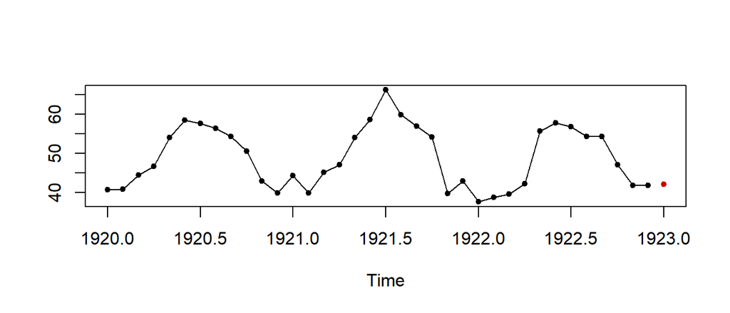

```r
plot(pred)
```

$~$$~$ **knnForecast** nesnesi aracılığıyla bunun grafiğini çizdirebileceğimizden bahsetmiştik. Grafiğimizi çizdirdiğimizde; y ekseninde Fahrenheit değerleri ve x ekseninde yıllarımız yer almaktadır. Tahmin edilen değerimiz kırmızı nokta ile grafikte belirtilmiştir.

$~$$~$ Yeni örneği, en yakın komşularını ve tahmini içeren olay örgüsü aşağıdaki grafik ile de görselleştirilebilir: (Bu grafik için “ggplot2” kütüphanesine ihtiyaç vardır.)

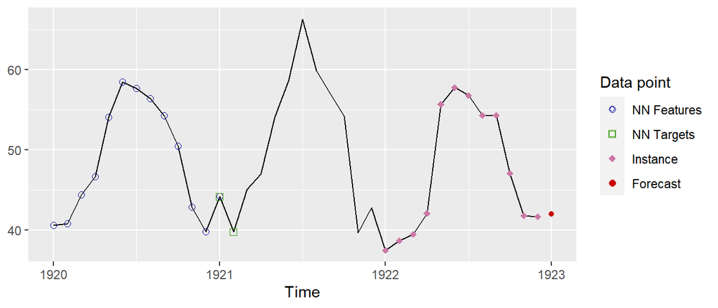

```r
autoplot(pred, highlight = "neighbors",faceting=F)
```

$~$$~$ Bu grafik bize 4 farklı sembol ile görsellik sağlar.

**Bu semboller:**

1. Forecast: Tahmin edilen değeri gösterir.
2. Instance: Tahmin etmeye çalıştığımız hedefin özellik vektörüne ait değerleri gösterir.
3. NN Targets: En yakın k komşudaki hedef değerleri gösterir.
4. NN Features: En yakın k komşudaki özellik vektörüne ait değerleri gösterir.

# Çok Adımlı İleriye Dönük Stratejiler

$~$$~$ Bir önceki bölümde, KNN ile bir adım ileri tahmin için örnek yapmıştık. Aynı zamanda, gelecekte birden fazla değeri tahmin etmekte çok yaygın bir kullanımdadır. Bu amaçla, çok adımlı bir ileri strateji seçilerek çoklu tahmin yapılabilir. Bu pakette iki ortak strateji vardır:

1. MIMO—Çoklu Girdi Çoklu Çıktı Stratejisi
2. Özyinelemeli Strateji
- Yalnızca bir gelecek değeri tahmin edildiğinde her iki stratejide aynı çalışma mantığını göstermektedir.

### MIMO Stratejisi - Multiple-Input and Multiple-Output

$~$$~$ Çoklu Girdi Çoklu Çıktı stratejisi yaygın olarak KNN ile uygulanır ve hedef değerlerin bir vektörünün kullanılması ile karakterize edilir. Bu vektörün uzunluğu tahmin edilecek periyotların sayısına eşittir. Örneğin, Büyük Britanya’da aylık ölen toplam otomobil sürücülerini veren bir zaman serisiyle çalıştığımızı varsayalım ve önümüzdeki 12 ay için ölenlerin sayısını tahmin etmek istiyoruz. Bu durumda, özellik olarak kullanılan gecikmeler için iyi bir seçim 1:12 olacaktır.

$~$$~$ Eğer MIMO stratejisi seçilirse, bir eğitim örneği şunlardan oluşur:

• 12 ay ardışık ölüm sayılarına sahip bir hedef vektör ve

• Ardışık önceki 12 aydaki ölümlerin sayısını gösteren bir özellik vektörü–hedef vektörün 12 ayından hemen önce.

$~$$~$ Yeni örnek(instance), zaman serisinin son 12 ayında ölen araba sürücülerinin sayısı olacaktır. Bu şekilde, zaman serilerinde son 12 aya en çok benzeyen ölüm sayısını ararız ve sonraki 12 ayı tahmin ederiz.

- Aşağıdaki örnekte, MIMO stratejisini kullanarak önümüzdeki 12 ayı tahmin etmeye çalışacağız:

```
##       Jan  Feb  Mar  Apr  May  Jun  Jul  Aug  Sep  Oct  Nov  Dec
## 1969 1687 1508 1507 1385 1632 1511 1559 1630 1579 1653 2152 2148
## 1970 1752 1765 1717 1558 1575 1520 1805 1800 1719 2008 2242 2478
## 1971 2030 1655 1693 1623 1805 1746 1795 1926 1619 1992 2233 2192
## 1972 2080 1768 1835 1569 1976 1853 1965 1689 1778 1976 2397 2654
## 1973 2097 1963 1677 1941 2003 1813 2012 1912 2084 2080 2118 2150
## 1974 1608 1503 1548 1382 1731 1798 1779 1887 2004 2077 2092 2051
## 1975 1577 1356 1652 1382 1519 1421 1442 1543 1656 1561 1905 2199
## 1976 1473 1655 1407 1395 1530 1309 1526 1327 1627 1748 1958 2274
## 1977 1648 1401 1411 1403 1394 1520 1528 1643 1515 1685 2000 2215
## 1978 1956 1462 1563 1459 1446 1622 1657 1638 1643 1683 2050 2262
## 1979 1813 1445 1762 1461 1556 1431 1427 1554 1645 1653 2016 2207
## 1980 1665 1361 1506 1360 1453 1522 1460 1552 1548 1827 1737 1941
## 1981 1474 1458 1542 1404 1522 1385 1641 1510 1681 1938 1868 1726
## 1982 1456 1445 1456 1365 1487 1558 1488 1684 1594 1850 1998 2079
## 1983 1494 1057 1218 1168 1236 1076 1174 1139 1427 1487 1483 1513
## 1984 1357 1165 1282 1110 1297 1185 1222 1284 1444 1575 1737 1763
```

$~$$~$ **UKDriverDeaths** veri seti; Ocak 1969 ile Aralık 1984 arasında Büyük Britanya’da ölen veya ciddi şekilde yaralanan araç sürücülerinin aylık toplamını veren bir zaman serisidir.

$~$$~$ Örneğimizi daha iyi açıklayabilmek için veri setinde ilk 3 yılı ele alıp 1972 yılındaki ölen veya ciddi şekilde yaralanan araç sürücülerinin aylık toplamını tahmin etmeye çalışacağız.

$~$$~$ knn_forecasting fonksiyonun **msas** argümanına **“MIMO”** yazarak çoklu girdi çoklu çıktı stratejisini uygulayabiliriz.

```r
mimoTimeS <- window(UKDriverDeaths,end=c(1971,12))
mimoTimeS
```

```
##       Jan  Feb  Mar  Apr  May  Jun  Jul  Aug  Sep  Oct  Nov  Dec
## 1969 1687 1508 1507 1385 1632 1511 1559 1630 1579 1653 2152 2148
## 1970 1752 1765 1717 1558 1575 1520 1805 1800 1719 2008 2242 2478
## 1971 2030 1655 1693 1623 1805 1746 1795 1926 1619 1992 2233 2192
```

```r
mimoPred <- knn_forecasting(mimoTimeS, h= 12, lags = 1:12, k=2, msas = "MIMO")
knn_examples(mimoPred)
```

```
##       Lag12 Lag11 Lag10 Lag9 Lag8 Lag7 Lag6 Lag5 Lag4 Lag3 Lag2 Lag1   H1   H2
##  [1,]  1687  1508  1507 1385 1632 1511 1559 1630 1579 1653 2152 2148 1752 1765
##  [2,]  1508  1507  1385 1632 1511 1559 1630 1579 1653 2152 2148 1752 1765 1717
##  [3,]  1507  1385  1632 1511 1559 1630 1579 1653 2152 2148 1752 1765 1717 1558
##  [4,]  1385  1632  1511 1559 1630 1579 1653 2152 2148 1752 1765 1717 1558 1575
##  [5,]  1632  1511  1559 1630 1579 1653 2152 2148 1752 1765 1717 1558 1575 1520
##  [6,]  1511  1559  1630 1579 1653 2152 2148 1752 1765 1717 1558 1575 1520 1805
##  [7,]  1559  1630  1579 1653 2152 2148 1752 1765 1717 1558 1575 1520 1805 1800
##  [8,]  1630  1579  1653 2152 2148 1752 1765 1717 1558 1575 1520 1805 1800 1719
##  [9,]  1579  1653  2152 2148 1752 1765 1717 1558 1575 1520 1805 1800 1719 2008
## [10,]  1653  2152  2148 1752 1765 1717 1558 1575 1520 1805 1800 1719 2008 2242
## [11,]  2152  2148  1752 1765 1717 1558 1575 1520 1805 1800 1719 2008 2242 2478
## [12,]  2148  1752  1765 1717 1558 1575 1520 1805 1800 1719 2008 2242 2478 2030
## [13,]  1752  1765  1717 1558 1575 1520 1805 1800 1719 2008 2242 2478 2030 1655
##         H3   H4   H5   H6   H7   H8   H9  H10  H11  H12
##  [1,] 1717 1558 1575 1520 1805 1800 1719 2008 2242 2478
##  [2,] 1558 1575 1520 1805 1800 1719 2008 2242 2478 2030
##  [3,] 1575 1520 1805 1800 1719 2008 2242 2478 2030 1655
##  [4,] 1520 1805 1800 1719 2008 2242 2478 2030 1655 1693
##  [5,] 1805 1800 1719 2008 2242 2478 2030 1655 1693 1623
##  [6,] 1800 1719 2008 2242 2478 2030 1655 1693 1623 1805
##  [7,] 1719 2008 2242 2478 2030 1655 1693 1623 1805 1746
##  [8,] 2008 2242 2478 2030 1655 1693 1623 1805 1746 1795
##  [9,] 2242 2478 2030 1655 1693 1623 1805 1746 1795 1926
## [10,] 2478 2030 1655 1693 1623 1805 1746 1795 1926 1619
## [11,] 2030 1655 1693 1623 1805 1746 1795 1926 1619 1992
## [12,] 1655 1693 1623 1805 1746 1795 1926 1619 1992 2233
## [13,] 1693 1623 1805 1746 1795 1926 1619 1992 2233 2192
```

$~$$~$ **Peki nasıl çalışır ?**

- İlk özellik vektörü zaman serisindeki ilk yılın 12 ayıdır.
- İlk hedef vektörü ise zaman serisindeki ikinci yılın 12 ayıdır.
- İkinci özellik vektörü, zaman serisindeki ilk yılın ilk ayından hemen sonraki 12 aydır.
- İkinci hedef vektörü ise zaman serisindeki ikinci yılın ilk ayından hemen sonraki 12 aydır.
- Üçüncü özellik vektörü, zaman serisindeki ilk yılın ikinci ayından hemen sonraki 12 aydır.
- Üçüncü hedef vektörü ise, zaman serisindeki ikinci yılın ikinci ayından hemen soraki 12 aydır.
- …
- n’inci özellik vektörü, zaman serisindeki sondan bir önceki yılın 12 ayıdır.
- n’inci hedef vektörü ise zaman serisindeki son yılın 12 ayıdır.

$~$$~$ Özellik olarak gecikmeleri 1: 12’yi kullandığımız için, zaman serisinin bir sonraki gelecek değerlerin (1972 yılının 12 ayı) özellik vektörü, zaman serisinin son 12 ayıdır. nearest_neighbors fonksiyonu ile hedefi tahmin edilen yeni örneğe ve en yakın komşularıa bakalım:

```r
nearest_neighbors(mimoPred)
```

```
## $instance
## Lag 12 Lag 11 Lag 10  Lag 9  Lag 8  Lag 7  Lag 6  Lag 5  Lag 4  Lag 3  Lag 2
##   2030   1655   1693   1623   1805   1746   1795   1926   1619   1992   2233
##  Lag 1
##   2192
##
## $nneighbors
##   Lag 12 Lag 11 Lag 10 Lag 9 Lag 8 Lag 7 Lag 6 Lag 5 Lag 4 Lag 3 Lag 2 Lag 1
## 1   1752   1765   1717  1558  1575  1520  1805  1800  1719  2008  2242  2478
## 2   2148   1752   1765  1717  1558  1575  1520  1805  1800  1719  2008  2242
##     H1   H2   H3   H4   H5   H6   H7   H8   H9  H10  H11  H12
## 1 2030 1655 1693 1623 1805 1746 1795 1926 1619 1992 2233 2192
## 2 2478 2030 1655 1693 1623 1805 1746 1795 1926 1619 1992 2233
```

- **nearest_neighbors** fonksiyonu bize tahmin etmeye çalıştığımız hedefin yeni örneği veya özellik vektörünü ve bu özellik vektörüne en yakın olan 2 komşusunun özellik ve hedef vektörünü verir.

$~$$~$ **En yakın iki komşu ise şu şekilde belirlenir:**

$~$$~$ Bir hedef vektöründe tahmin etmeye çalıştığımız 12 ay olduğu için ve veri setindeki son 12 ay bizim bir sonraki yılın 12 ayını tahmin etmek için kullandığımız özellik vektörü olmasından dolayı algoritma veri setindeki son 12 aya kadar devam eder. Bu durumda 2. yılın ilk ayından itibaren 12 li periodlar halinde seçtiğimizde 13 tane özellik vektörü ve bu özellik vektörlerinin hedef vektörlerini elde ederiz.

$~$$~$ knn_examples(pred) ile elde ettiğimiz gecikmeleri ve hedefleri bir matrise dönüştürerek en yakın 2 komşuyu kendimiz bulmak istersek:

```r
mimoOrnekler <- knn_examples(mimoPred)
mimoNN_instance <- nearest_neighbors(mimoPred)
mimoEuclidean <- c()
for (i in 1:nrow(mimoOrnekler)) {
  mimoEuclidean <- append(mimoEuclidean,sqrt(sum((mimoOrnekler[i,1:12] - mimoNN_instance$instance) ^ 2)))
}
mimoEnYakin2 <- as.data.frame(mimoEuclidean)
mimoEnYakin2 <- data.frame(Satir_No=row(mimoEnYakin2),Oklid_Mesafeleri=mimoEuclidean)
order(mimoEnYakin2$Oklid_Mesafeleri)
```

```
##  [1] 13 12  1  2 11  5 10  3  4  9  8  6  7
```

$~$$~$ Kendimiz elde etmek istediğimizde de öklid mesafelerine bakarak en yakın 2 komşunun, knn_examples(pred) sonucundaki 13. ve 12. satır olduğunu teyit etmiş olduk.

```r
mimoPred$prediction
```

```
##         Jan    Feb    Mar    Apr    May    Jun    Jul    Aug    Sep    Oct
## 1972 2254.0 1842.5 1674.0 1658.0 1714.0 1775.5 1770.5 1860.5 1772.5 1805.5
##         Nov    Dec
## 1972 2112.5 2212.5
```

$~$$~$ 1972 yılının 12 ayı için tahmin değerleri 2254.0 1842.5 1674.0 1658.0 1714.0 1775.5 1770.5 1860.5 1772.5 1805.5 2112.5 2212.5 adet olarak bulunmuştur. Bu değer, tahmin etmeye çalıştığımız hedefin özellik vektörüne en yakın olan 2 komşusunun hedef değerlerinin ortalamasıdır.

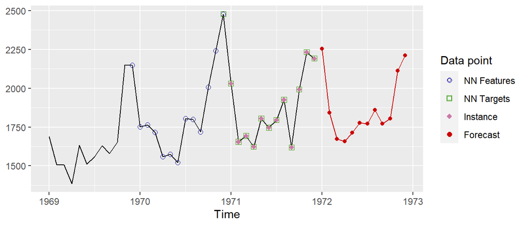

```r
autoplot(mimoPred,highlight = "neighbors",faceting=F)
```

$~$$~$ Zaman serilerinin son 12 değeri, hedefi tahmin edilmesi gereken yeni örneğin(instance) özellikleridir. Bu örneğe en çok benzeyen 12 ardışık değerden oluşan iki dizi(seri) bulunur (mavi renkte) ve sonraki 12 değerin (yeşil) ortalaması alınır ve tahmini değer (kırmızı) elde edilir.

### Özyinelemeli Strateji

$~$$~$ Özyinelemeli veya yinelemeli strateji, birkaç periyodu tahmin etmek için kullanılan yaklaşımdır. Bu stratejide sadece bir adım ileriyi tahmin eden bir model kullanılmaktadır. Bu nedenle, model tüm gelecek dönemleri tahmin etmek için yinelemeli olarak uygulanır. Yeni örneğin özellikleri olarak kullanılacak tarihsel gözlemler mevcut olmadığında, bunun yerine önceki tahminler kullanılır. $~$$~$ Özyinelemeli strateji bir adım ileri model kullandığı için, bunun anlamı, KNN durumunda, bir eğitim örneğinin hedefinin yalnızca bir değer içerdiği anlamına gelir. Örneğin, aylık bir zaman serisinin gelecek iki ayının tahmin edildiği aşağıdaki örnekle yinelemeli stratejinin nasıl çalıştığını inceleyelim:

```r
USAccDeaths
```

```
##        Jan   Feb   Mar   Apr   May   Jun   Jul   Aug   Sep   Oct   Nov   Dec
## 1973  9007  8106  8928  9137 10017 10826 11317 10744  9713  9938  9161  8927
## 1974  7750  6981  8038  8422  8714  9512 10120  9823  8743  9129  8710  8680
## 1975  8162  7306  8124  7870  9387  9556 10093  9620  8285  8466  8160  8034
## 1976  7717  7461  7767  7925  8623  8945 10078  9179  8037  8488  7874  8647
## 1977  7792  6957  7726  8106  8890  9299 10625  9302  8314  8850  8265  8796
## 1978  7836  6892  7791  8192  9115  9434 10484  9827  9110  9070  8633  9240
```

$~$$~$ **USAccDeaths** veri seti, 1973 ve 1978 yılları arasında ABD’deki kaza sonucu ölümlerin aylık toplamını veren bir zaman serisidir.

$~$$~$ knn_forecasting fonksiyonun **msas** argümanına **“recursive”** yazarak özyineleme stratejisini uygulayabiliriz.

```r
recursiveTimeS <- window(USAccDeaths,end=c(1975,12))
recursiveTimeS
```

```
##        Jan   Feb   Mar   Apr   May   Jun   Jul   Aug   Sep   Oct   Nov   Dec
## 1973  9007  8106  8928  9137 10017 10826 11317 10744  9713  9938  9161  8927
## 1974  7750  6981  8038  8422  8714  9512 10120  9823  8743  9129  8710  8680
## 1975  8162  7306  8124  7870  9387  9556 10093  9620  8285  8466  8160  8034
```

```r
recursivePred <- knn_forecasting(recursiveTimeS, h= 2, lags = 1:12, k=2, msas = "recursive")
knn_examples(recursivePred)
```

```
##       Lag12 Lag11 Lag10  Lag9  Lag8  Lag7  Lag6  Lag5  Lag4  Lag3  Lag2  Lag1
##  [1,]  9007  8106  8928  9137 10017 10826 11317 10744  9713  9938  9161  8927
##  [2,]  8106  8928  9137 10017 10826 11317 10744  9713  9938  9161  8927  7750
##  [3,]  8928  9137 10017 10826 11317 10744  9713  9938  9161  8927  7750  6981
##  [4,]  9137 10017 10826 11317 10744  9713  9938  9161  8927  7750  6981  8038
##  [5,] 10017 10826 11317 10744  9713  9938  9161  8927  7750  6981  8038  8422
##  [6,] 10826 11317 10744  9713  9938  9161  8927  7750  6981  8038  8422  8714
##  [7,] 11317 10744  9713  9938  9161  8927  7750  6981  8038  8422  8714  9512
##  [8,] 10744  9713  9938  9161  8927  7750  6981  8038  8422  8714  9512 10120
##  [9,]  9713  9938  9161  8927  7750  6981  8038  8422  8714  9512 10120  9823
## [10,]  9938  9161  8927  7750  6981  8038  8422  8714  9512 10120  9823  8743
## [11,]  9161  8927  7750  6981  8038  8422  8714  9512 10120  9823  8743  9129
## [12,]  8927  7750  6981  8038  8422  8714  9512 10120  9823  8743  9129  8710
## [13,]  7750  6981  8038  8422  8714  9512 10120  9823  8743  9129  8710  8680
## [14,]  6981  8038  8422  8714  9512 10120  9823  8743  9129  8710  8680  8162
```

[output cut: 35 more lines]

$~$$~$ **Peki nasıl çalışır ?**

- İlk özellik vektörü zaman serisindeki ilk yılın 12 ayıdır.
- İlk hedef vektörü ise zaman serisindeki ikinci yılın ilk ayıdır.
- İkinci özellik vektörü, zaman serisindeki ilk yılın ilk ayından hemen sonraki 12 aydır.
- İkinci hedef vektörü ise zaman serisine göre ilk hedef vektöründen hemen sonraki ilk aydır.
- Üçüncü özellik vektörü, zaman serisindeki ilk yılın ikinci ayından hemen sonraki 12 aydır.
- Üçüncü hedef vektörü ise,zaman serisine göre ikinci hedef vektöründen hemen sonraki ilk aydır.
- …
- n’inci özellik vektörü, zaman serisindeki son yılın son ayından hemen önceki 12 aydır.
- n’inci hedef vektörü ise zaman serisindeki son yılın son ayıdır.

$~$$~$ nearest_neighbors fonksiyonu ile hedefi tahmin edilen yeni örneğe ve en yakın komşularıa bakalım:

```r
nearest_neighbors(recursivePred)
```

```
## [[1]]
## [[1]]$instance
## Lag 12 Lag 11 Lag 10  Lag 9  Lag 8  Lag 7  Lag 6  Lag 5  Lag 4  Lag 3  Lag 2
##   8162   7306   8124   7870   9387   9556  10093   9620   8285   8466   8160
##  Lag 1
##   8034
##
## [[1]]$nneighbors
##   Lag 12 Lag 11 Lag 10 Lag 9 Lag 8 Lag 7 Lag 6 Lag 5 Lag 4 Lag 3 Lag 2 Lag 1
## 1   7750   6981   8038  8422  8714  9512 10120  9823  8743  9129  8710  8680
## 2   6981   8038   8422  8714  9512 10120  9823  8743  9129  8710  8680  8162
##     H1
## 1 8162
## 2 7306
##
##
## [[2]]
## [[2]]$instance
## Lag 12 Lag 11 Lag 10  Lag 9  Lag 8  Lag 7  Lag 6  Lag 5  Lag 4  Lag 3  Lag 2
##   7306   8124   7870   9387   9556  10093   9620   8285   8466   8160   8034
##  Lag 1
##   7734
##
## [[2]]$nneighbors
##   Lag 12 Lag 11 Lag 10 Lag 9 Lag 8 Lag 7 Lag 6 Lag 5 Lag 4 Lag 3 Lag 2 Lag 1
## 1   6981   8038   8422  8714  9512 10120  9823  8743  9129  8710  8680  8162
## 2   8038   8422   8714  9512 10120  9823  8743  9129  8710  8680  8162  7306
##     H1
## 1 7306
## 2 8124
```

**nearest_neighbors** fonksiyonu bize tahmin etmeye çalıştığımız hedeflerin yeni örneklerini veya özellik vektörlerini ve bu özellik vektörüne en yakın olan 2 komşularının özelliklerinin ve hedeflerinin vektörünü verir.

$~$$~$ **En yakın iki komşu ise şu şekilde belirlenir:**

$~$$~$ İlk olarak 1976 yılının Ocak ayını tahmin etmek için bir özellik vektörü ve en yakın 2 komşusunun özellik vektörü ve hedef değerlerini verdikten sonra tahmin edilen değer 1976 yılının Şubat ayını tahmin etmek için hedef değeri olarak ele alınır. Bu durumda 2. tahmin için özellik vektörü 1976 yılının Ocak ayı dahil geriye dönük ilk 12 aydır. 1976 yılının Ocak ayı ise ilk tahmin için en yakın 2 komşunun hedef değerlerinin ortalaması alınmış değeriydi. 2. tahmin için gerekli olan en yakın 2 komşu ise tüm özellik vektörleri üzerinde tekrar öklid hesaplayarak bulunur. **Bu hesaplamaya ilk tahmin etmeye çalıştığımız 1976 yılının Ocak ayına ait özellik vektörünü dahil etmez.**

- **knn_examples(pred)** ile elde ettiğimiz gecikmeleri ve hedefleri bir matrise dönüştürerek en yakın 2 komşuyu kendimiz bulmak istersek:

```r
recursiveOrnekler <- knn_examples(recursivePred)
recursiveNN_instance <- nearest_neighbors(recursivePred)

recursiveEuclidean1 <- c()
recursiveEuclidean2 <- c()
for (i in 1:nrow(recursiveOrnekler)) {
  recursiveEuclidean1 <- append(recursiveEuclidean1,sqrt(sum((recursiveOrnekler[i,1:12] - recursiveNN_instance[[1]]$instance) ^ 2)))
}
for (i in 1:nrow(recursiveOrnekler)) {
  recursiveEuclidean2 <- append(recursiveEuclidean2,sqrt(sum((recursiveOrnekler[i,1:12] - recursiveNN_instance[[2]]$instance) ^ 2)))
}
recursiveEnYakin2_1 <- as.data.frame(recursiveEuclidean1)
recursiveEnYakin2_1 <- data.frame(Satir_No=row(recursiveEnYakin2_1),Oklid_Mesafeleri=recursiveEuclidean1)
recursiveEnYakin2_2 <- as.data.frame(recursiveEuclidean2)
recursiveEnYakin2_2 <- data.frame(Satir_No=row(recursiveEnYakin2_2),Oklid_Mesafeleri=recursiveEuclidean2)
```

```r
order(recursiveEnYakin2_1$Oklid_Mesafeleri)
```

```
##  [1] 13 14 24 15 12 23 16  1 11 17  2 22 18  3 20 10 19 21  4  9  5  8  6  7
```

```r
order(recursiveEnYakin2_2$Oklid_Mesafeleri)
```

```
##  [1] 14 15 16 13 24 17  2 12  3 18 23  1 19  4 11 22 21 20  5 10  6  9  7  8
```

$~$$~$ Kendimiz elde etmek istediğimizde de öklid mesafelerine bakarak ilk tahmin için en yakın 2 komşunun, knn_examples(pred) sonucundaki 13. ve 14. satır olduğunu ve 2. tahmin için en yakın 2 komşunun, knn_examples(pred) sonucundaki 14. ve 15. özellik vektörleri olduğunu bu kod ile de teyit etmiş olduk.

```r
recursivePred$prediction
```

```
##       Jan  Feb
## 1976 7734 7715
```

$~$$~$ 1976 yılının Ocak ayını 7734 ve Şubat ayını 7715 adet olarak bulmuştur.. Bu değer, tahmin etmeye çalıştığımız hedeflerin özellik vektörüne en yakın olan 2 komşusunun hedef değerlerinin ortalamasıdır.

[figure not shown]

```r
autoplot(mimoPred,highlight = "neighbors",faceting=F)
```

#### Farklı k parametrelerine sahip birkaç modelden oluşan bir topluluk

$~$$~$ Tsfknn paketi ile bu stratejiyi k değerlerinin bir vektörünü belirleyerek kullanabilirsiniz:

```r
predK <- knn_forecasting(ldeaths, h = 12, lags = 1:12, k = c(2, 4))
predK$prediction
```

```
##           Jan      Feb      Mar      Apr      May      Jun      Jul      Aug
## 1980 2865.375 2866.250 2728.875 2189.000 1816.000 1625.875 1526.250 1404.250
##           Sep      Oct      Nov      Dec
## 1980 1354.000 1541.250 1699.250 2198.750
```

$~$$~$ Birden fazla k tanımlaması yaparak tahminleme yapmak **MIMO** stratejisi tabanlıdır. Önce k=2 için daha sonra k=4 için çalışır.Oluşan iki modelin tahmin($prediction) değerlerinin ortalamasını alır.

$~$$~$ Bu örnekte, k sırasıyla 2 ve 4’e eşit olan iki KNN modeli oluşturulmuştur. Tahmin, her iki model tarafından üretilen tahminlerin ortalamasıdır.

# Varsayılan parametreler

$~$$~$ Bazen çok sayıda zaman serisinin tahmin edilmesi gerekir. Bu durumda, tahminleri oluşturmanın otomatik bir yolu çok kullanışlıdır. Bu anlamda, bu pakette mantıklı varsayılan parametreleri kullanabilir. Kullanıcı yalnızca zaman serisini ve tahmin ufkunu belirtirse, KNN parametreleri aşağıdaki gibi seçilir:

- Çok adımlı ileriye dönük strateji olarak MIMO seçilmiştir.
- Hedefleri toplamak için kullanılan kombinasyon işlevi ortalamadır.
- k sırasıyla 3, 5 ve 7 en yakın komşuyu kullanan üç modelin kombinasyonu olarak seçilir.
- Otoregresif gecikmeleri seçmek için aşağıdaki strateji kullanılır:

$~$$~$ Zaman serisi mevsimsel ise ve mevsimsel dönemin uzunluğu m ise, 1: m gecikmeler kullanılır. Örneğin, üç aylık veri gecikmeleri için 1: 4 ve aylık veri gecikmeleri için 1:12 seçilir. Bu şekilde mevsimsel desenler daha kolay yakalanabilir.

# Tahmin doğruluğunu değerlendirme

$~$$~$ Bir model oluşturulduktan sonra, tahmin doğruluğunu değerlendirmek istenebilir. Tsfknn paketinde bu, rolling_origin fonksiyonu ile yapılır. Bu fonksiyon, bir veri kümesini eğitim ve test kümelerine ayırmanın klasik yaklaşımını kullanır.

$~$$~$ Zaman serisi tahmininde test seti, zaman serilerinin son gözlemlerinden oluşur. Örneğin:

```
##       Jan  Feb  Mar  Apr  May  Jun  Jul  Aug  Sep  Oct  Nov  Dec
## 1974 3035 2552 2704 2554 2014 1655 1721 1524 1596 2074 2199 2512
## 1975 2933 2889 2938 2497 1870 1726 1607 1545 1396 1787 2076 2837
## 1976 2787 3891 3179 2011 1636 1580 1489 1300 1356 1653 2013 2823
## 1977 3102 2294 2385 2444 1748 1554 1498 1361 1346 1564 1640 2293
## 1978 2815 3137 2679 1969 1870 1633 1529 1366 1357 1570 1535 2491
## 1979 3084 2605 2573 2143 1693 1504 1461 1354 1333 1492 1781 1915
```

$~$$~$ **ldeaths** veri seti 1974-1979 arasında İngiltere’de bronşit, amfizem ve astımdan aylık ölümleri gösteren bir zaman serisidir.

```r
pred <- knn_forecasting(ldeaths, h = 12, lags = 1:12, k = 2)
ro <- rolling_origin(pred, h = 6, rolling = FALSE)
ro
```

```
## $knnf
##
## Call:  knn_forecasting(timeS = ldeaths, h = 12, lags = 1:12, k = 2)
##
## Multiple-Step Ahead Strategy: MIMO
## K (number of nearest neighbors): 2
## Autoregressive lags: 1 2 3 4 5 6 7 8 9 10 11 12
## Number of examples: 49
## Targets are combined using the mean function.
##
## $test_sets
##       h=1  h=2  h=3  h=4  h=5  h=6
## [1,] 1461 1354 1333 1492 1781 1915
##
## $predictions
##         h=1    h=2    h=3  h=4    h=5  h=6
## [1,] 1513.5 1363.5 1351.5 1567 1587.5 2392
##
## $errors
##        h=1  h=2   h=3 h=4   h=5  h=6
## [1,] -52.5 -9.5 -18.5 -75 193.5 -477
##
## $global_accu
##       RMSE        MAE       MAPE
## 213.613748 137.666667   7.747168
##
## $h_accu
##            h=1       h=2       h=3      h=4       h=5       h=6
## RMSE 52.500000 9.5000000 18.500000 75.00000 193.50000 477.00000
## MAE  52.500000 9.5000000 18.500000 75.00000 193.50000 477.00000
## MAPE  3.593429 0.7016248  1.387847  5.02681  10.86468  24.90862
##
## attr(,"class")
## [1] "knnForecastRO"
```

$~$$~$ Örneğin, test seti, tahminler ve hatalara başvurulabilir:

```r
ro$test_sets
```

```
##       h=1  h=2  h=3  h=4  h=5  h=6
## [1,] 1461 1354 1333 1492 1781 1915
```

$~$$~$ Zaman serisi verisinin son 6 verisi yani 1979 yılının son 6 ayı test veri seti olarak ayarlanmıştır.

```r
ro$predictions
```

```
##         h=1    h=2    h=3  h=4    h=5  h=6
## [1,] 1513.5 1363.5 1351.5 1567 1587.5 2392
```

```r
ro$errors
```

```
##        h=1  h=2   h=3 h=4   h=5  h=6
## [1,] -52.5 -9.5 -18.5 -75 193.5 -477
```

$~$$~$ Zaman serisi veri setindeki son 6 ay test veri seti olarak ayarlanmış ve yine son 6 ay için tahminler knn_forecasting fonksiyonu ile hesaplanır. Test ve tahmin değerleri arasındaki fark hatalar olarak listelenebilir.

$~$$~$ Tahminler hakkında birkaç tahmin doğruluğu ölçüsüne başvurmak da mümkündür.

### Bazı doğruluk ölçüleri

#### [MSE] Ortalama Kare Hata (Mean Squared Error):

$$MSE=\frac{1}{n}\sum_{j=1}^n e_j^2$$

#### [RMSE] Kök Ortalama Kare Hata (Root Mean Square Error):

$$RMSE=\sqrt{\frac{\sum_{j=1}^{n} e_j^2}{n}}$$

$$RMSE=\sqrt{MSE}$$

#### [MAPE] Ortalama Mutlak Yüzde Hata (Mean Absolute Percentage Error):

$$MAPE=\frac{100}{n}\sum_{j=1}^n \frac{|e_j|}{|A_j|}$$

#### [MAE] Ortalama Mutlak Hata (Mean Absolute Error):

$$MAE=\frac{1}{n}\sum_{j=1}^n |e_j|$$

```r
ro$global_accu
```

```
##       RMSE        MAE       MAPE
## 213.613748 137.666667   7.747168
```

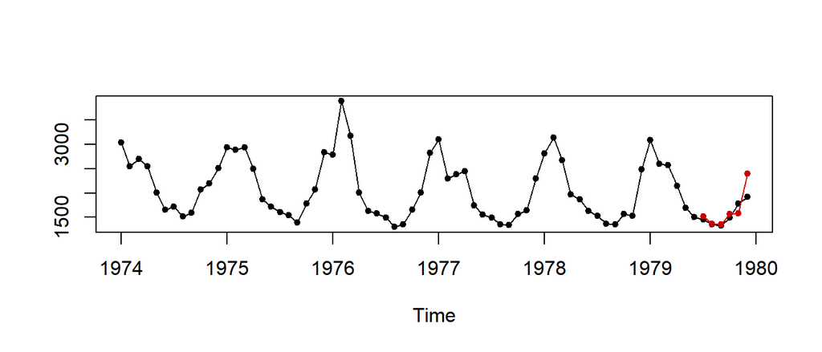

```r
plot(ro)
```

$~$$~$ Bu şekilde, zaman serilerinin son altı gözlemi test setidir ve tahminler kırmızı noktalardır.

# Diğer Zaman Serisi Tahmin Paketleriyle Karşılaştırma

**Aşağıda, bu paketlerin kısa bir açıklaması verilmiştir:**

**GMDH**

$~$$~$ Bu pakette, tek değişkenli bir zaman serisi için kısa vadeli tahmin yapmak için GMDH tipi sinir ağı algoritmaları uygulanmaktadır (Dag ve Yozgatligil, 2016). Veri işleme grup yöntemi (GMDH) türünde sinir ağı algoritmaları, karmaşık sistemleri modellemeye yarayan bulgusal, kendi kendini organize eden yöntemlerdir.

**NTS**

$~$$~$ Bu paket, kullanıcıların bir sinir ağını beslemek için gereken örnekleri oluşturmasına olanak tanıyan **NNsetting** fonksiyonunu içerir. Ancak paket, tahminlerin doğrudan oluşturulmasına izin vermez.

**tsDyn**

$~$$~$ Kullanıcıların, **nnet** paketinden **nnet** fonksiyonu kullanılarak hesaplanan tek bir gizli katman ile çok katmanlı bir algılayıcı kullanarak bir zaman serisini tahmin etmelerini sağlar.

- Doğrusal olmayan otoregresif (AR) zaman serisi modellerinde uygulanır.

**nnfor**

$~$$~$ Çok katmanlı algılayıcılar oluşturmak için **neuralnet** paketini kullanılır. **elm** fonksiyonu aracılığıyla aşırı öğrenme makinelerini kullanmak da mümkündür.

**forecast**

$~$$~$ Bu paket, gizli bir katmana sahip çok katmanlı bir algılayıcı kullanarak bir zaman serisini tahmin etmek için kullanılan **nnetar** fonksiyonunu kullanır.

$~$$~$ Aşağıdaki özellikler açısından bu paketlerin bir karşılaştırmasını tablo şeklinde görebiliriz:

- Keyfi otoregresif gecikmeler kullanmak mümkün müdür? Örneğin bazı paketlerde gecikmeler ardışık değerler olmalıdır.
- Yalnızca zaman serilerini ve tahmin ufkunu gösteren tahminleri oluşturmak mümkün müdür?
- Tahminleri ve diğer bilgileri plot ile çizmek için paket araçları içeriyor mu?
- Rolling origin (Dönen kaynak) değerlendirmesi uygulanıyor mu?
- Paket tahminler için tahmin aralıkları oluşturuyor mu?

| Paketler | GMDH | tsDyn | nnfor | forecast | tsfknn |
| --- | --- | --- | --- | --- | --- |
| Keyfi Gecikmeler | Hayır | Hayır | Evet | Hayır | Evet |
| Varsayılan Parametreler | Evet | Hayır | Evet | Evet | Evet |
| Plot Çizimi | Hayır | Evet | Evet | Evet | Evet |
| Rolling Orijin Değerlendirmesi | Hayır | Hayır | Evet | Evet | Evet |
| Tahmin Aralıkları | Evet | Hayır | Hayır | Evet | Hayır |

$~$$~$ Tahmin doğruluğuna ve çalışma süresine göre bu paketlerde bulunan yöntemlerin bir karşılaştırması yapılmıştır.. Bu amaçla, NN3 tahmin yarışmasından elde edilen veriler kullanılmıştır.

| PackageOrFunction | tsDyn | elm | mlp | nnetar | auto.arima | ets | tsfknn |
| --- | --- | --- | --- | --- | --- | --- | --- |
| MAPE | 20.73 | 18.76 | 20.95 | 18.38 | 15.64 | 15.52 | 17.06 |
| Time | 2 | 3332 | 690 | 15 | 421 | 105 | 4 |

# SONUÇ

$~$$~$ Bu yazıda, kullanıcıların KNN regresyonunu kullanarak bir zaman serisini tahmin etmelerini sağlayan tsfknn paketi sunulmuştur. Paketin arayüzü oldukça basittir ve kullanıcıların bir KNN modeli belirlemesine ve modeli kullanarak bir zaman serisini tahmin etmesine olanak tanır. Ayrıca, tahminin nasıl hesaplandığını gösteren birkaç grafik oluşturulabilir.